# Calculating dimensions of stability using species abundance data in response to multiple stressors - SI analysis

Lydia White

2022-04-20

Workflow for supplementary analysis and figures in Rush Paper 1 REVISED. Data & Code can be made available with the paper.

```r
library(readr)
data <- read_csv(here::here("data","RUSH_MACRO_Concise.csv"))
```

```r
library(tidyverse)
library(vegan)
library(lsmeans)
library(emmeans)
library(car)
library(lme4)
library(lmerTest)
library(ggh4x)
library(patchwork)
library(ggpubr)
library(rstatix)
```

# Compare cover and composition: Intact vs caged controls

First we can explore community responses to stressors in control and intact communities immediately after distubance period (so month 12)

Treatments: A Algae B Algae & Grazers C Algae, Grazers & Whelks D Uncaged control plot

N0 No Nutrients N1 Enriched with Nutrients S0 No Sediment S1 Sediment added

Functional responses are based on total percentage cover of all algal species as a proxy for biomass. Total percentage cover values often exceeded 100% due to the multi-layered nature of macroalgal communities.

```r
data$Plot <- gsub("24\\*", "100", data$Plot)

cols <-data %>% select(Fuc_Ves:Hilden) # columns of interest i.e. species

functional<- data%>%
  mutate_if(is.numeric, ~replace(., is.na(.), 0))%>%
   mutate(sum = rowSums(cols)) %>%
   select(Time:Treatment,sum) %>%
    filter(Time > 5 ) %>%
    rename(TAC = `sum`)
```

We compare total algal cover for disturbance treatments. Following the main analysis i have not included the multistressor treatment.

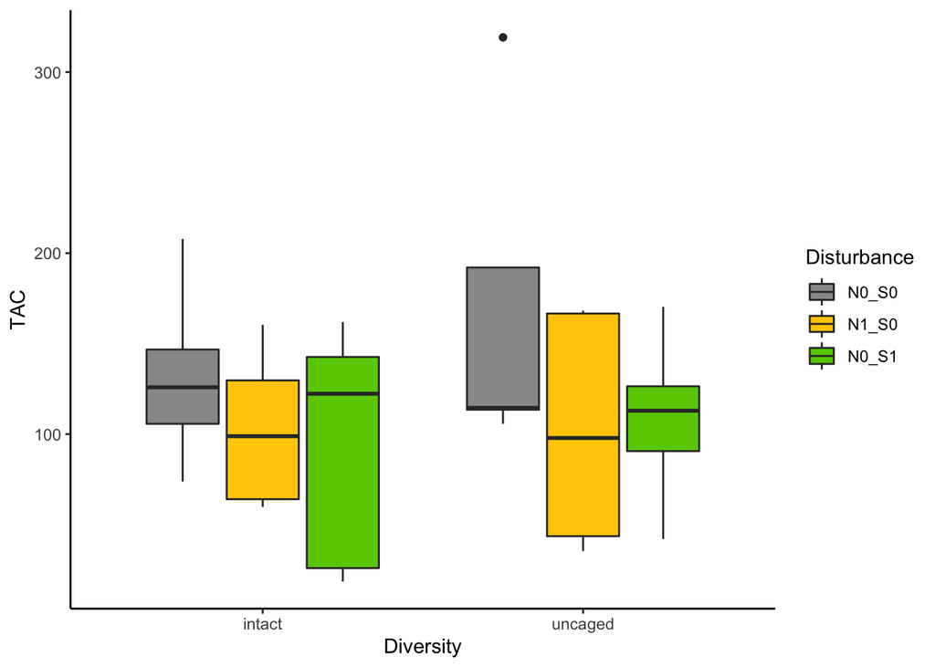

```r
intact<- functional%>%separate(Treatment, c("Diversity", "Nutrients","Sediment"), remove = F)%>%
  unite(Disturbance,c("Nutrients","Sediment"),sep="_")%>%
  filter(Time == 12 & Diversity == 'C' | Time == 12 & Diversity == 'D')%>%
  filter(Disturbance  != 'N1_S1' )%>%
  mutate(Disturbance = as_factor(Disturbance))%>%
  mutate(Diversity = as_factor(Diversity))

ggplot(intact, aes(x=Diversity, y=TAC))+
  geom_boxplot(aes(fill = Disturbance))+
  scale_fill_manual(values = c("#999999", "#FFCC00","#66CC00","red3"))+
  theme_classic()+
  scale_x_discrete(labels=c("A" = "W & G loss", "B" = "W loss", "C" = "intact", "D" = "uncaged"))
```

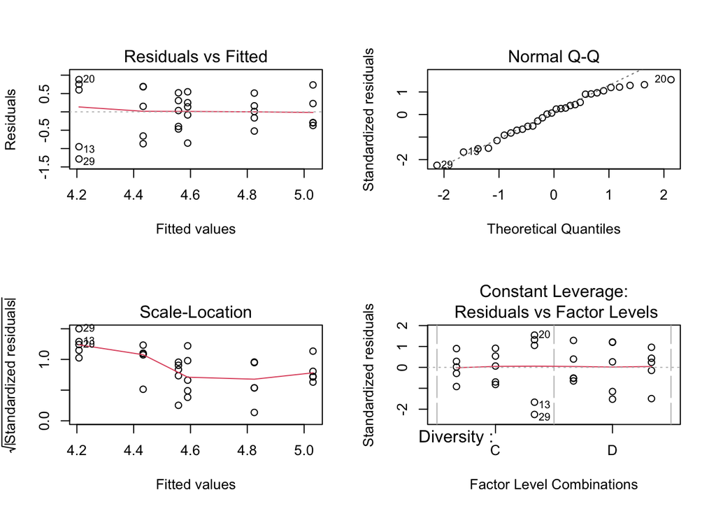

```r
mod1<-lm(log(TAC)~Diversity + Diversity:Disturbance, data = intact)

par(mfrow=c(2,2))
plot(mod1)
```

```r
par(mfrow=c(1,1))
anova(mod1)
```

```
## Analysis of Variance Table
##
## Response: log(TAC)
##                       Df Sum Sq Mean Sq F value Pr(>F)
## Diversity              1 0.1802 0.18019  0.4438 0.5116
## Diversity:Disturbance  4 1.9203 0.48007  1.1825 0.3436
## Residuals             24 9.7436 0.40598
```

Compositional responses

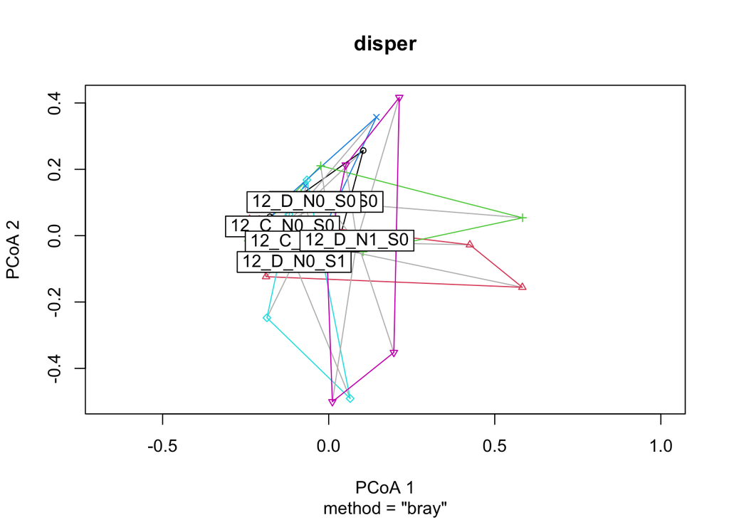

```r
env<- data%>%
  select(Plot, Time:Treatment)%>%
  unite("Treatment_Time", Time,Treatment, remove = FALSE)%>%
  separate(Treatment, c("Diversity", "Nutrients","Sediment"), remove = F)%>%
  unite(Disturbance,c("Nutrients","Sediment"),sep="_")%>%
  filter(Time == 12 & Diversity == 'C'|Time == 12 & Diversity == 'D') %>%
  filter(Disturbance  != 'N1_S1' )

dat<- data%>%
  separate(Treatment, c("Diversity", "Nutrients","Sediment"), remove = F)%>%
  unite(Disturbance,c("Nutrients","Sediment"),sep="_")%>%
  unite("Treatment_Time", Time,Treatment, remove = FALSE)%>%
  relocate(Diversity:Disturbance, .after = Treatment)%>%
  filter(Time == 12 & Diversity == 'C'|Time == 12 & Diversity == 'D')%>%
   filter(Disturbance  != 'N1_S1' )%>%
  mutate(Time = as_factor(Time))%>%
  mutate(Disturbance = as_factor(Disturbance))


dist_bc <- vegdist((dat[8:42]), method = 'bray')
disper=betadisper(dist_bc, dat$Treatment_Time)

plot(disper)
```

```r
anova(disper)
```

```
## Analysis of Variance Table
##
## Response: Distances
##           Df  Sum Sq  Mean Sq F value Pr(>F)
## Groups     5 0.08004 0.016008  0.3785 0.8585
## Residuals 24 1.01500 0.042292
```

```r
adonis(log10(1 + dat[8:42]) ~ Diversity + Diversity:Disturbance, data = dat, permutations = 9999)
```

```
##
## Call:
## adonis(formula = log10(1 + dat[8:42]) ~ Diversity + Diversity:Disturbance,      data = dat, permutations = 9999)
##
## Permutation: free
## Number of permutations: 9999
##
## Terms added sequentially (first to last)
##
##                       Df SumsOfSqs MeanSqs F.Model      R2 Pr(>F)
## Diversity              1   0.15167 0.15167  1.6241 0.05334 0.1433
## Diversity:Disturbance  4   0.45021 0.11255  1.2052 0.15834 0.2450
## Residuals             24   2.24135 0.09339         0.78831
## Total                 29   2.84323                 1.00000
```

```r
pairwise.adonis <- function(x,factors, sim.function = 'vegdist', sim.method = 'bray', p.adjust.m ='bonferroni')
{

co = combn(unique(as.character(factors)),2)
pairs = c()
F.Model =c()
R2 = c()
p.value = c()


for(elem in 1:ncol(co)){
if(sim.function == 'daisy'){
library(cluster); x1 = daisy(x[factors %in% c(co[1,elem],co[2,elem]),],metric=sim.method)
} else{x1 = vegdist(x[factors %in% c(co[1,elem],co[2,elem]),],method=sim.method)}

ad = adonis(x1 ~ factors[factors %in% c(co[1,elem],co[2,elem])] );
pairs = c(pairs,paste(co[1,elem],'vs',co[2,elem]));
F.Model =c(F.Model,ad$aov.tab[1,4]);
R2 = c(R2,ad$aov.tab[1,5]);
p.value = c(p.value,ad$aov.tab[1,6])
}
p.adjusted = p.adjust(p.value,method=p.adjust.m)
sig = c(rep('',length(p.adjusted)))
sig[p.adjusted <= 0.05] <-'.'
sig[p.adjusted <= 0.01] <-'*'
sig[p.adjusted <= 0.001] <-'**'
sig[p.adjusted <= 0.0001] <-'***'

pairw.res = data.frame(pairs,F.Model,R2,p.value,p.adjusted,sig)
print("Signif. codes:  0 ‘***’ 0.001 ‘**’ 0.01 ‘*’ 0.05 ‘.’ 0.1 ‘ ’ 1")
return(pairw.res)

}
```

without using log transformed abundance data

```r
adonis((dat[8:42]) ~ Diversity*Disturbance, data = dat, permutations = 9999)
```

```
##
## Call:
## adonis(formula = (dat[8:42]) ~ Diversity * Disturbance, data = dat,      permutations = 9999)
##
## Permutation: free
## Number of permutations: 9999
##
## Terms added sequentially (first to last)
##
##                       Df SumsOfSqs MeanSqs F.Model      R2 Pr(>F)
## Diversity              1    0.3112 0.31117 1.69767 0.05773 0.1162
## Disturbance            2    0.4245 0.21224 1.15794 0.07876 0.3234
## Diversity:Disturbance  2    0.2552 0.12761 0.69622 0.04735 0.7713
## Residuals             24    4.3990 0.18329         0.81616
## Total                 29    5.3899                 1.00000
```

# Compare cover and composition: apriori differences between plots

Compare TAC and assembalge between treatments at T0.

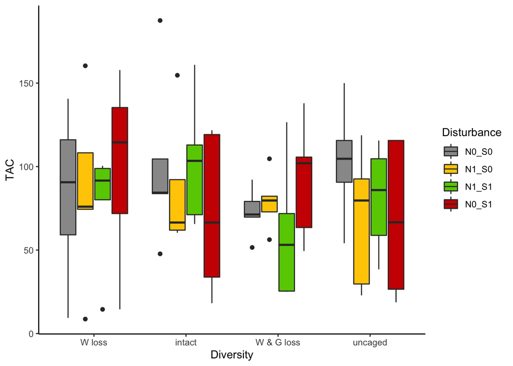

```r
functional_T0<- data%>%
  mutate_if(is.numeric, ~replace(., is.na(.), 0))%>%
   mutate(sum = rowSums(cols)) %>%
   select(Time:Treatment,sum) %>%
    filter(Time == 0 ) %>%
    rename(TAC = `sum`) %>%separate(Treatment, c("Diversity", "Nutrients","Sediment"), remove = F)%>%
  unite(Disturbance,c("Nutrients","Sediment"),sep="_")%>%
  mutate(Disturbance = as_factor(Disturbance))%>%
  mutate(Diversity = as_factor(Diversity))

ggplot(functional_T0, aes(x=Diversity, y=TAC))+
  geom_boxplot(aes(fill = Disturbance))+
  scale_fill_manual(values = c("#999999", "#FFCC00","#66CC00","red3"))+
  theme_classic()+
  scale_x_discrete(labels=c("A" = "W & G loss", "B" = "W loss", "C" = "intact", "D" = "uncaged"))
```

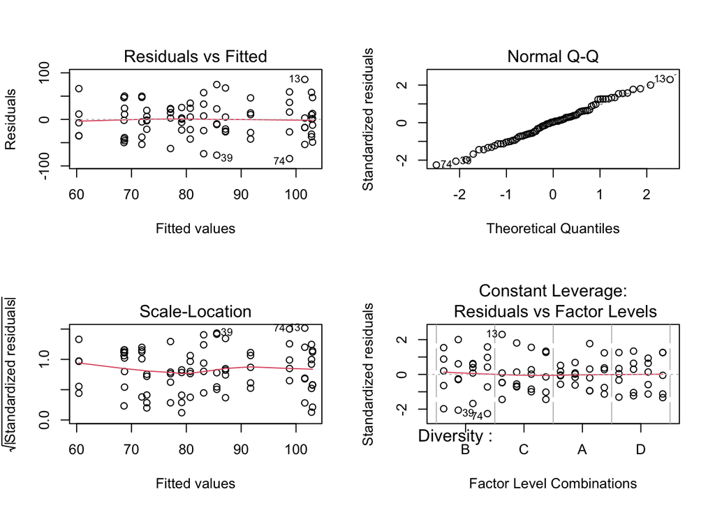

```r
mod1<-lm((TAC)~Diversity*Disturbance, data = functional_T0)

par(mfrow=c(2,2))
plot(mod1)
```

```r
par(mfrow=c(1,1))
anova(mod1)
```

```
## Analysis of Variance Table
##
## Response: (TAC)
##                       Df Sum Sq Mean Sq F value Pr(>F)
## Diversity              3   2553  850.95  0.4879 0.6919
## Disturbance            3   1326  441.92  0.2534 0.8587
## Diversity:Disturbance  9   9575 1063.87  0.6099 0.7841
## Residuals             64 111629 1744.20
```

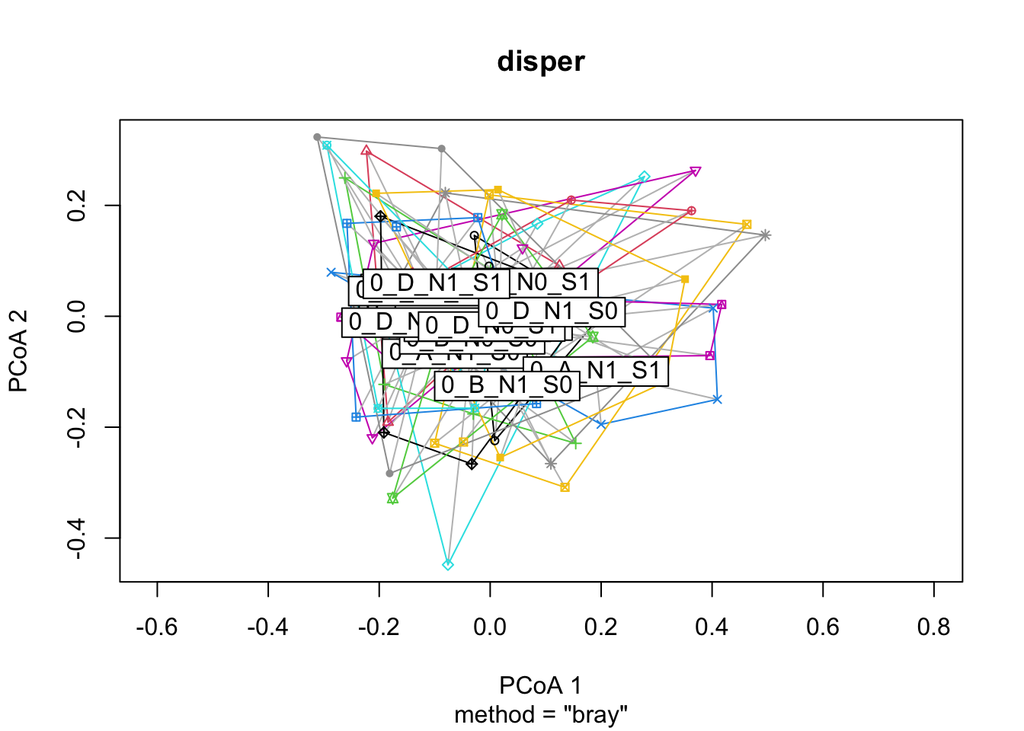

```r
env<- data%>%
  select(Plot, Time:Treatment)%>%
  unite("Treatment_Time", Time,Treatment, remove = FALSE)%>%
  separate(Treatment, c("Diversity", "Nutrients","Sediment"), remove = F)%>%
  unite(Disturbance,c("Nutrients","Sediment"),sep="_")%>%
  filter(Time == 0)

dat<- data%>%
  separate(Treatment, c("Diversity", "Nutrients","Sediment"), remove = F)%>%
  unite(Disturbance,c("Nutrients","Sediment"),sep="_")%>%
  unite("Treatment_Time", Time,Treatment, remove = FALSE)%>%
  relocate(Diversity:Disturbance, .after = Treatment)%>%
  filter(Time == 0)%>%
  mutate(Disturbance = as_factor(Disturbance))%>%
  mutate(Diversity = as_factor(Diversity))


dist_bc <- vegdist((dat[8:42]), method = 'bray')
disper=betadisper(dist_bc, dat$Treatment_Time)

plot(disper)
```

```r
anova(disper)
```

```
## Analysis of Variance Table
##
## Response: Distances
##           Df  Sum Sq  Mean Sq F value Pr(>F)
## Groups    15 0.11675 0.007783   0.372 0.9817
## Residuals 64 1.33917 0.020925
```

```r
adonis(log10(1 + dat[8:42]) ~ Diversity*Disturbance, data = dat, permutations = 9999)
```

```
##
## Call:
## adonis(formula = log10(1 + dat[8:42]) ~ Diversity * Disturbance,      data = dat, permutations = 9999)
##
## Permutation: free
## Number of permutations: 9999
##
## Terms added sequentially (first to last)
##
##                       Df SumsOfSqs  MeanSqs F.Model      R2 Pr(>F)
## Diversity              3    0.4612 0.153732 1.31925 0.05169 0.1393
## Disturbance            3    0.1746 0.058209 0.49952 0.01957 0.9833
## Diversity:Disturbance  9    0.8288 0.092091 0.79028 0.09289 0.8967
## Residuals             64    7.4579 0.116529         0.83585
## Total                 79    8.9225                  1.00000
```

# Compare stability: Intact vs caged controls

Functional stability is calculated using total percentage cover of all algal species as a proxy for biomass. Total percentage cover values often exceeded 100% due to the multi-layered nature of macroalgal communities. To calculate stability values we are only interested in data following the perturbation, month 6 onwards.

## Functional stability

We calculate 4 different metrics using total algal cover data from the time period following the perturbations (months 6 to 15).

### Temporal variability

Temporal variability is calculated as the coefficient of variance (CV; that is, standard deviation divided by the mean) of total algal cover in each experimental plot over time during the pertubation phase. Detrended to remove potentially confounding effects of biomass change over the duration of the experiment.

We run linear models on total algal cover in each plot over time and use the residuals from these models to calculate the CV

```r
tmp<-functional%>%
  select(Diversity,Plot,Time, TAC,Treatment)%>%
  filter(Time < 13)

tmp = split(tmp,tmp$Plot)

resids<-lapply(names(tmp),function(X){
  Y <- tmp[[X]]
  A <-residuals(lm(TAC~Time, data = Y))
  B <-Y$Diversity
  B2<-Y$Treatment
  C <-Y$Time
  D <-Y$TAC
  E <-sd(A)/mean(D)
  data_frame(Plot=X,Residuals=A, Diversity=B, Treatment = B2, Time=C, TAC =D, Temp.Var=E)
})

Temp_Var<-lapply(resids,function(X){
  X[1,]
}) %>%
  Reduce("rbind",.)%>%
  select(Plot,Diversity,Treatment,Temp.Var)
```

### Spatial variability

Spatial variability was calculated as the CV of total algal cover among experimental plots within each stressor vs. consumer loss treatment combination on each census during the pertubation phase. Detrended to remove potentially confounding effects of biomass change over the duration of the experiment.

So we use the residuals from the previous linear regressions. This time we divide SD of the residuals across plots for each time period by the mean total algal cover.

```r
Spatial_Var<- Reduce("rbind",resids)%>%
  select(Time,Plot,Diversity,Treatment, Residuals,TAC)%>%
  group_by(Time, Diversity, Treatment) %>%
  summarise(Spa.Var = sd(Residuals)/mean(TAC))
```

### Resistance

Resistance and resilience are associated with a perturbation, they can only be calculated by comparing algal cover in perturbed treatments to cover within unperturbed treatments.

Resistance was defined as the log response ratio (LRR) of total algal cover in a perturbed relative to unperturbed plot at th end of the perturbation phase. We calculated the LRR of total algal cover in each perturbed plot relative to the mean cover in unperturbed plots for the corresponding consumer loss treatment, for the final time point (month 12) during the perturbation phase (months 6 - 12).

```r
mean_cover<-functional %>%
   filter (Time == 12 & Nutrients == 'N0' & Sediment == 'S0') %>%
  group_by(Diversity, Time)%>%
  summarise(meanTAC = mean(TAC))

cover<-functional %>%
   filter (Time == 12 ) %>%
  select(Diversity,Treatment,Time,Plot,TAC)


LRR_Resist<-left_join(cover,mean_cover)%>%
  mutate(LRR_TAC = log(TAC/meanTAC))%>%
  filter(Treatment != 'A_N0_S0' & Treatment != 'B_N0_S0' & Treatment != 'C_N0_S0' &   Treatment != 'D_N0_S0')%>%
  rename(Resist = LRR_TAC)%>%
 select(Plot, Diversity, Treatment, Resist)
```

### Resilience

Resilience is the slope of linear regression of the log response ratio over time from the end of the pertubation phase to the end of the experiment. Calculating the log difference is equivalent to calculating the rate of relative return, rather than the absolute rate, rendering resilience at least conceptually independent from resistance. So we run a lm on LRR in between months 12 and months 15.

```r
mean_cover<-functional %>%
   filter (Time > 11 & Nutrients == 'N0' & Sediment == 'S0') %>%
  group_by(Diversity, Time)%>%
  summarise(meanTAC = mean(TAC))

cover<-functional %>%
   filter (Time > 11) %>%
  select(Diversity,Treatment,Time,Plot,TAC)

LRR<-left_join(cover,mean_cover)%>%
  mutate(LRR_TAC = log(TAC/meanTAC))

Resil<-lapply(1:nrow(LRR_Resist),function(i){
  X = LRR_Resist[i,]
  tmp =  filter(LRR,Plot == X$Plot)
  tmp<-lm(LRR_TAC~Time,data = tmp)
  coef2 = tmp$coefficients["Time"]
  data_frame(Plot=X$Plot,Resilience=coef2)
})%>% Reduce("rbind",.)
```

We can compile all the stabilty measures. For the few cases where perturbations increased biomass and, therefore, resulted in a positive resistance value, resilience was then multiplied by -1. We can plot the raw stabilty measures as boxplots.

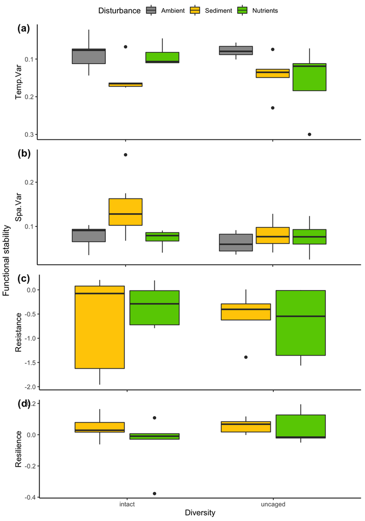

```r
Stability_metrics<-left_join(LRR_Resist,Resil)%>%
  mutate(Resilience = ifelse(Resist >0, Resilience*-1, Resilience))%>%
  select(Plot,Diversity,Treatment,Resist,Resilience)%>%
  gather(key = metric, value = value, -Diversity, -Treatment, -Plot)%>%
  rename(rep = Plot)

Temp_Var<-Temp_Var%>%
gather(key = metric, value = value,  -Diversity, -Treatment, -Plot)%>%
rename(rep = Plot)

Spatial_Var<-Spatial_Var%>%
gather(key = metric, value = value,  -Diversity, -Treatment, -Time)%>%
rename(rep = Time )%>%
ungroup(rep)%>%
mutate(rep = as.factor(rep))

x <-rbind(Stability_metrics, Temp_Var,data.frame(Spatial_Var))%>%
  separate(Treatment, c("Diversity", "Nutrients","Sediment"), remove = F)%>%
  unite(Disturbance,c("Nutrients","Sediment"),sep="_")%>%
  filter(Disturbance != "N1_S1")%>%
  mutate(metric = factor(metric,levels = c( "Temp.Var", "Spa.Var", "Resist", "Resilience")))%>%
  mutate(Disturbance = plyr::mapvalues(Disturbance, from = c("N0_S0","N0_S1","N1_S0"), to = c("Ambient","Sediment","Nutrients")))%>%
  mutate(Disturbance = factor(Disturbance,levels = c("Ambient", "Sediment","Nutrients")))

x_sub<-x %>%
filter(Diversity == "C"|Diversity == "D")

A <-ggplot(data = subset(x_sub,
              metric == "Temp.Var"), aes(x=Diversity, y=value)) +
  geom_boxplot(aes(fill = Disturbance)) +
  theme_classic()+
  ylab("Temp.Var") +
  scale_fill_manual(values = c("#999999", "#FFCC00","#66CC00")) +
  scale_y_reverse()

B<-ggplot(data = subset(x_sub,
              metric == "Spa.Var"), aes(x=Diversity, y=value)) +
  geom_boxplot(aes(fill = Disturbance)) +
  theme_classic()+
  ylab("Spa.Var") +
  scale_fill_manual(values = c("#999999", "#FFCC00","#66CC00"))

C<-ggplot(data = subset(x_sub,
              metric == "Resist"), aes(x=Diversity, y=value)) +
  geom_boxplot(aes(fill = Disturbance)) +
  theme_classic()+
  ylab("Resistance") +
  scale_fill_manual(values = c("#FFCC00","#66CC00"))

D<-ggplot(data = subset(x_sub,
              metric == "Resilience"), aes(x=Diversity, y=value)) +
  geom_boxplot(aes(fill = Disturbance)) +
  theme_classic()+
  ylab("Resilience") +
  scale_fill_manual(values = c("#FFCC00","#66CC00")) +
  scale_x_discrete(labels=c("C" = "intact", "D" = "uncaged"))

P <- ggarrange(A + rremove("xlab") + rremove("x.text"), B + rremove("xlab") + rremove("x.text"),C + rremove("xlab") + rremove("x.text"), D, heights = c(1, 1,1,1), ncol = 1, nrow = 4,common.legend = T, labels = c("(a)", "(b)", "(c)", "(d)"))

annotate_figure(P, left = text_grob("Functional stability", rot = 90))
```

## Compositional Stability

For compositional stability, we originally calculated bray-curtis distance matrices from the log10 x +1 transformed species abundance data in PRIMER V6. But have redone all the analysis in R, all metrics were calculated with the aim of being analogous to functional measures, where possible. As for funtional stability, we calculate 4 different metrics using algal cover data from the time period following the perturbations (months 6 to 15).

### Temporal variability

Mean Euclidean distance from each experimental plot, on every census (months 6 to 12), to the plot centroid, based on Bray–Curtis dissimilarity matrices calculated from algal cover data.

```r
dat<- data%>%
   filter(Time > 5 & Time < 13)%>%
   unite("Treatment_Time",Treatment, Time, remove = FALSE)

dist_bc <- vegdist(log10(1+dat[9:43]), method = 'bray')
mod <- betadisper(dist_bc, dat$Plot)
dat$dist <- mod$distances

Temp_Var_Comp<- dat  %>%
  group_by(Plot)%>%
  summarise(Temp.Var = mean(dist), Diversity = unique(Diversity), Treatment = unique(Treatment) )
```

### Spatial variability

Mean Euclidean distance from each experimental plot to their grazer treatment centroid, calculated separately for each census (months 6 to 12), based on Bray–Curtis dissimilarity matrices calculated from algal cover data.

```r
dat<- data%>%
   filter(Time > 5 & Time < 13)%>%
   unite("Treatment_Time",Treatment, Time, remove = FALSE)

dist_bc <- vegdist(log10(1+dat[9:43]), method = 'bray')
mod <- betadisper(dist_bc, dat$Treatment_Time)  ####### gives mean distance between plots and their centroid

Spatial_Var_Comp<-aggregate(mod$distances,list(dat$Treatment_Time),mean)%>%
 rename(Spa.Var = x, centroid = Group.1)
```

### Resistance, Resilience

For Resistance & Resilience, we used pairwise distances in the same way as LRR values for functional stability, calculating metrics from the temporal trajectory of these LRR values. As for functional stability, these metrics are all associated with a perturbation and can only be calculated by comparing algal assemblage in perturbed treatments to assemblages in unperturbed treatments.

Because of heterogeneous dispersions between consumer loss treatments (ANOVA results below), we calculated the log response ratio of the mean Euclidian distance between all plots in a given perturbed treatment and their own centroid and that from a perturbed plot to the centroid of the unperturbed plots in the corresponding consumer loss treatment. i.e. ln(mean Euclidian distance between all plots in a given perturbed treatment and their own centroid/Euclidian distance from a perturbed plot to the centroid of the unperturbed plots in the corresponding consumer loss treatment)

This effectively takes into account the variabilty amongst plots for a given consumer loss group.

We calculated this LRR for every perturbed plot at the time point at the end of the pertubation phase and during the three month recovery phase after the perturbations (month 12 - 15). And then calculated the remaining stability metrics in exactly the same way as for functional stability.

```r
dat<- data%>%
   filter(Time > 11) %>%
   unite("Treatment_Time", Treatment, Time, remove = FALSE)%>%
   unite("Treatment_Time_Plot",Treatment, Time, Plot, remove = FALSE)

dat<-dat[order(dat$Treatment_Time_Plot),]
dis <- vegdist(log10(1+dat[10:44 ]), method = 'bray')

mod <- betadisper(dis, dat$Treatment)
anova(mod) ### check for dispersion between treatments
```

```
## Analysis of Variance Table
##
## Response: Distances
##            Df Sum Sq  Mean Sq F value    Pr(>F)
## Groups     15 1.1806 0.078708  3.4175 2.219e-05 ***
## Residuals 304 7.0014 0.023031
## ---
## Signif. codes:  0 '***' 0.001 '**' 0.01 '*' 0.05 '.' 0.1 ' ' 1
```

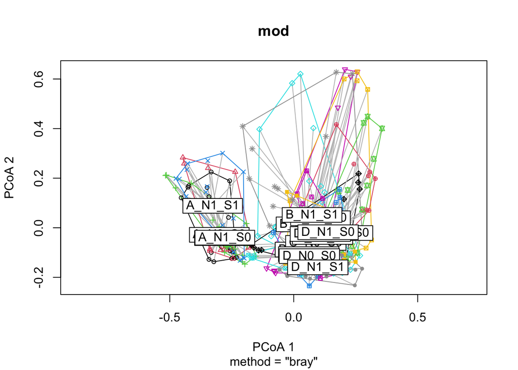

```r
plot(mod)
```

```r
fullmod <- betadisper(dis, dat$Treatment_Time)

fancier_function <- function(X,Y,Z){
  tmp <- Z$vectors[X,] ### the positions of each plot in all pCoA axis (n of plots -1)
  tmp.pos <- tmp[Z$eig>=0]   ### the real part
  tmp.neg <- tmp[Z$eig<0]   ### the imaginary part

  tmp.cent <- Z$centroids[Y,] ### the positions of each centroid
  tmp.cent.pos <- tmp.cent[Z$eig>=0]
  tmp.cent.neg <- tmp.cent[Z$eig<0]

  real.euc <- dist(t(data.frame(tmp.pos,tmp.cent.pos))) ### real distances
  imag.euc<- dist(t(data.frame(tmp.neg,tmp.cent.neg))) ### imaginary distances
  as.vector(sqrt(abs(real.euc^2 - imag.euc^2))) # need the sqrt of the difference between real and imaginary parts following Anderson 2006
}

Test<-sapply(1:5, function(X) fancier_function(X,"A_N0_S0_12", fullmod)) # can compare Test vs head(fullmod$distances) to check its working properly

names<-dat$Treatment_Time_Plot %>% as.character()

## converts Treatment_Time_Plot to Treatment_Time using "regular expressions"
tmp2 <- data.frame(Treatment_Time_Plot=names,centroid=gsub("_[^_]+$", "", names),stringsAsFactors = F) # gsub looks for something that starts with an underscore followed by a single or multiple letter or number at the end of the name and replaces it with "nothing" thus removing the last portion of the sampe name

tmp2$centroid<-sub("_N[0-1]_S[0-1]_","_N0_S0_",tmp2$centroid) ### converts to unperturbed centroid code
Test2<-sapply(1:320, function(X) fancier_function(X,tmp2$centroid[X], fullmod)) # now apply the funciton to every row in our mod 2 table for every centroid in our centroid table)

Distances<-cbind(Test2,tmp2)%>%
 rename(ED = Test2)%>%
   separate(Treatment_Time_Plot, c("Diversity", "Nutrients","Sediment", "Time","Plot"))%>%
  unite("Treatment_Time", Diversity, Nutrients, Sediment, Time, remove = FALSE)

dat<- data%>%
   filter(Time > 11)%>%
   unite("Treatment_Time",Treatment, Time, remove = FALSE)

dist_bc <- vegdist(log10(1+dat[9:43]), method = 'bray')
mod <- betadisper(dist_bc, dat$Treatment_Time)

Spatial_Var_Comp_recovery<-aggregate(mod$distances,list(dat$Treatment_Time),mean)%>%
 rename(Spa.Var = x, Treatment_Time = Group.1)

LRR_Comp<-left_join(Distances, Spatial_Var_Comp_recovery)%>%
  mutate(LRR_COMP = log(Spa.Var/ED))%>%
  mutate(Time = as.numeric(Time))%>%
  unite(Treatment,c("Diversity", "Nutrients","Sediment"),sep="_", remove = F)%>%
  select(Diversity, Treatment, Time, Plot, ED, Spa.Var, LRR_COMP)

LRR_Resist_Comp<-LRR_Comp%>%
  filter(Time == 12)%>%
  filter(Treatment != 'A_N0_S0' & Treatment != 'B_N0_S0' & Treatment != 'C_N0_S0' &   Treatment != 'D_N0_S0')%>%
  rename(Resist =  LRR_COMP)%>%
  select(Plot, Diversity, Treatment, Resist)

Resil_Comp<-lapply(1:nrow(LRR_Resist_Comp),function(i){
  X = LRR_Resist_Comp[i,]
  tmp =  filter(LRR_Comp,Plot == X$Plot)
  tmp<-lm(LRR_COMP~Time,data = tmp)
  coef2 = tmp$coefficients["Time"]
  data_frame(Plot=X$Plot,Resilience=coef2)
})%>% Reduce("rbind",.)
```

We can compile all the stabilty measures. For the few cases where perturbations increased similarity to control plots and, therefore, resulted in a positive resistance value, resilience was then multiplied by -1. We can plot the raw stabilty measures as boxplots.

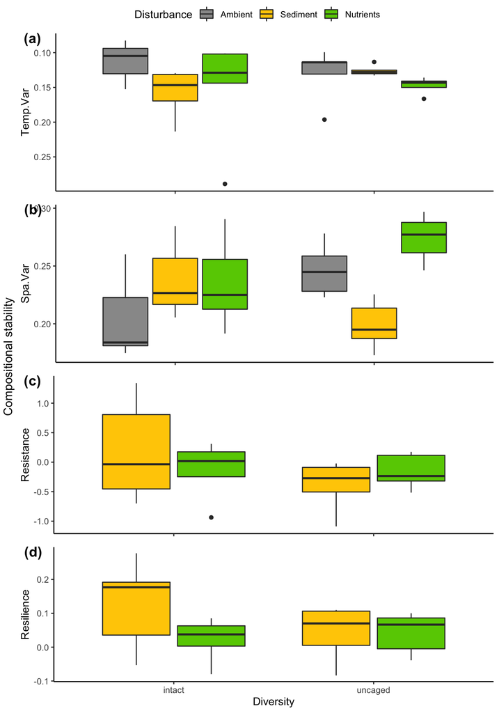

```r
Stability_metrics_Comp<-left_join(Resil_Comp,LRR_Resist_Comp)%>%
mutate(Resilience = ifelse(Resist >0, Resilience*-1, Resilience))%>%
  select(Plot,Diversity,Treatment,Resist,Resilience)%>%
  gather(key = metric, value = value, -Diversity, -Treatment, -Plot)%>%
  rename(rep = Plot)

Temp_Var_Comp<-Temp_Var_Comp %>%
  select(Plot,Diversity,Treatment,Temp.Var)%>%
  gather(key = metric, value = value, -Diversity, -Treatment, -Plot)%>%
  rename(rep = Plot)

Spatial_Var_Comp<-Spatial_Var_Comp%>%
  separate(centroid, c("Diversity", "Nutrients","Sediment", "Time"))%>%
  unite(Treatment,c("Diversity", "Nutrients","Sediment"),sep="_", remove = F)%>%
  select(-Nutrients, -Sediment)%>%
  gather(key = metric, value = value,  -Diversity, -Treatment, -Time)%>%
  rename(rep = Time )%>%
  mutate(rep = as.factor(rep))

x_Comp <-rbind(Stability_metrics_Comp, Temp_Var_Comp, Spatial_Var_Comp)%>%
  separate(Treatment, c("Diversity", "Nutrients","Sediment"), remove = F)%>%
  unite(Disturbance,c("Nutrients","Sediment"),sep="_")%>%
  filter(Disturbance != "N1_S1") %>%
  mutate(metric = factor(metric,levels = c( "Temp.Var", "Spa.Var", "Resist", "Resilience")))%>%
  mutate(Disturbance = plyr::mapvalues(Disturbance, from = c("N0_S0","N0_S1","N1_S0"), to = c("Ambient","Sediment","Nutrients")))%>%
  mutate(Disturbance = factor(Disturbance,levels = c("Ambient", "Sediment","Nutrients")))

x_Comp_sub<-x_Comp %>%
  filter(Diversity == "C"|Diversity == "D")

A <-ggplot(data = subset(x_Comp_sub,
              metric == "Temp.Var"), aes(x=Diversity, y=value)) +
  geom_boxplot(aes(fill = Disturbance)) +
  theme_classic()+
  ylab("Temp.Var") +
  scale_fill_manual(values = c("#999999", "#FFCC00","#66CC00")) +
  scale_y_reverse()

B<-ggplot(data = subset(x_Comp_sub,
              metric == "Spa.Var"), aes(x=Diversity, y=value)) +
  geom_boxplot(aes(fill = Disturbance)) +
  theme_classic()+
  ylab("Spa.Var") +
  scale_fill_manual(values = c("#999999", "#FFCC00","#66CC00"))

C<-ggplot(data = subset(x_Comp_sub,
              metric == "Resist"), aes(x=Diversity, y=value)) +
  geom_boxplot(aes(fill = Disturbance)) +
  theme_classic()+
  ylab("Resistance") +
  scale_fill_manual(values = c("#FFCC00","#66CC00"))

D<-ggplot(data = subset(x_Comp_sub,
              metric == "Resilience"), aes(x=Diversity, y=value)) +
  geom_boxplot(aes(fill = Disturbance)) +
  theme_classic()+
  ylab("Resilience") +
  scale_fill_manual(values = c("#FFCC00","#66CC00")) +
  scale_x_discrete(labels=c("C" = "intact", "D" = "uncaged"))

P <- ggarrange(A + rremove("xlab") + rremove("x.text"), B + rremove("xlab") + rremove("x.text"),C + rremove("xlab") + rremove("x.text"), D, heights = c(1, 1,1,1), ncol = 1, nrow = 4,common.legend = T, labels = c("(a)", "(b)", "(c)", "(d)"))

annotate_figure(P, left = text_grob("Compositional stability", rot = 90))
```

# ANOVAs for Cage effects on stability

We run ANOVAs on each stability metric, seperately for functional and compositional measures. We test for main effects of cages and for their interaction with disturbance on stability. And calculate pairwise comparisons using estimated marginal means with tukey adjustment for multiple comparisons.

Have log transformed values to improve homogeneity and normality of residuals, resistance and resilience had to be range standardised before transformation, to convert to positive transformable values.

All ns.

```r
x$response<-"Function"
x_Comp$response<-"Composition"

combined <-rbind(x,x_Comp) %>%
  filter(Diversity =="C"|Diversity =="D")%>%
  filter(Treatment !="C_N1_S1"|Treatment !="D_N1_S1")%>%
  separate(Treatment, c("Diversity", "Nutrients","Sediment")) %>%
  unite(Disturbance,c("Nutrients","Sediment"),sep="_")%>%
  unite(var,c("response","metric"),sep="_", remove = F)%>%
  mutate(Diversity = as.factor(Diversity))%>%
  mutate(Disturbance = as.factor(Disturbance))%>%
  filter(metric !="Spa.Var")


v = unique(combined$var)
res1<-list()
res2<-list()

for(i in v){
tmp<-lm(value~Diversity + Diversity:Disturbance, data = combined%>%filter(var == i))
  E <- rstandard(tmp)
  S<-shapiro.test(E)
  L<- leveneTest(value~ Diversity*Disturbance, data = combined%>%filter(var == i))
  A<-anova(tmp)
  TR <- "no_transfo"

  if(S$p.value <= 0.05){
    if(grepl("Var$",i)){
      combined_tmp <-combined%>%filter(var == i)
      tmp<-lm(log(value)~Diversity + Diversity:Disturbance, data = combined_tmp)
      E <- rstandard(tmp)
      S<-shapiro.test(E)
      L<- leveneTest(log(value)~ Diversity*Disturbance, data = combined_tmp)
      A<-anova(tmp)
      TR <- "log_transfo"
    }else{
      combined_tmp <- mutate(combined, value = rangestand(value) +0.01)%>%filter(var == i)
      tmp<-lm(log(value)~Diversity + Diversity:Disturbance, data = combined_tmp)
      E <- rstandard(tmp)
      S<-shapiro.test(E)
      L<- leveneTest(log(value)~ Diversity*Disturbance, data = combined_tmp)
      A<-anova(tmp)
      TR <- "range_log_transfo"
    }
  }
  if(S$p.value <= 0.05){
    if(grepl("Resi",i)){
      combined_tmp <- mutate(combined, value = rangestand(value) +0.01)%>%filter(var == i)
      tmp<-lm((value)^3~Diversity + Diversity:Disturbance, data = combined_tmp)
      E <- rstandard(tmp)
      S<-shapiro.test(E)
      L<- leveneTest((value)^3~Diversity*Disturbance, data = combined_tmp)
      A<-anova(tmp)
      TR <- "range_cb_transfo"
    }
  }

  table1<-data.frame(Normality=S$p.value, Homogeneity=L$`Pr(>F)`[1], Var = i, Transformation = TR)
  table2<-data.frame(A)

  res1[[i]] <-table1
  res2[[i]] <-table2
}

res1%>% Reduce("rbind",.)
```

```
##    Normality Homogeneity                    Var Transformation
## 1 0.13999373   0.5191062        Function_Resist     no_transfo
## 2 0.12125734   0.7184479    Function_Resilience     no_transfo
## 3 0.07028694   0.5586507      Function_Temp.Var     no_transfo
## 4 0.66515160   0.2704654     Composition_Resist     no_transfo
## 5 0.22446905   0.5374705 Composition_Resilience     no_transfo
## 6 0.01147029   0.3187117   Composition_Temp.Var    log_transfo
```

```r
res2
```

```
## $Function_Resist
##                       Df     Sum.Sq    Mean.Sq   F.value    Pr..F.
## Diversity              1 0.06940239 0.06940239 0.1345621 0.7185542
## Diversity:Disturbance  2 0.36804526 0.18402263 0.3567957 0.7053451
## Residuals             16 8.25223591 0.51576474        NA        NA
##
## $Function_Resilience
##                       Df     Sum.Sq    Mean.Sq  F.value    Pr..F.
## Diversity              1 0.01758263 0.01758263 1.277193 0.2750793
## Diversity:Disturbance  2 0.02790680 0.01395340 1.013568 0.3850757
## Residuals             16 0.22026590 0.01376662       NA        NA
##
## $Function_Temp.Var
##                       Df     Sum.Sq     Mean.Sq   F.value     Pr..F.
## Diversity              1 0.00238129 0.002381290 0.8725999 0.35954054
## Diversity:Disturbance  4 0.03004444 0.007511109 2.7523712 0.05142301
## Residuals             24 0.06549502 0.002728959        NA         NA
##
## $Composition_Resist
##                       Df    Sum.Sq   Mean.Sq   F.value    Pr..F.
## Diversity              1 0.4599121 0.4599121 1.4645448 0.2437842
## Diversity:Disturbance  2 0.4121960 0.2060980 0.6562987 0.5321843
## Residuals             16 5.0244924 0.3140308        NA        NA
##
## $Composition_Resilience
##                       Df      Sum.Sq     Mean.Sq   F.value    Pr..F.
## Diversity              1 0.005140802 0.005140802 0.6432672 0.4342815
## Diversity:Disturbance  2 0.026982101 0.013491050 1.6881315 0.2161721
## Residuals             16 0.127867291 0.007991706        NA        NA
##
## $Composition_Temp.Var
##                       Df       Sum.Sq      Mean.Sq     F.value   Pr..F.
## Diversity              1 0.0005078968 0.0005078968 0.008274025 0.928278
## Diversity:Disturbance  4 0.3902829802 0.0975707450 1.589501569 0.209392
## Residuals             24 1.4732277886 0.0613844912          NA       NA
```

```r
mod1<-lm(value ~ Diversity + Diversity:Disturbance, data = combined%>%filter(var == "Function_Temp.Var"))
```

For spatial variabilty we need to run linear mixed models with lmer and include time as a random factor. Calculate p-values from F-tests using Satterthwaite’s denominator df. And calculate pairwise comparisons using estimated marginal means with tukey adjustment for multiple comparisons.

```r
combined <-rbind(x,x_Comp) %>%
   filter(Diversity =="C"|Diversity =="D")%>%
  filter(Treatment !="C_N1_S1"|Treatment !="D_N1_S1")%>%
  separate(Treatment, c("Diversity", "Nutrients","Sediment")) %>%
  unite(Disturbance,c("Nutrients","Sediment"),sep="_")%>%
  unite(var,c("response","metric"),sep="_", remove = F)%>%
  mutate(Diversity = as.factor(Diversity))%>%
  mutate(Disturbance = as.factor(Disturbance))%>%
  filter(metric =="Spa.Var")

v = unique(combined$var)

res1<-list()
res2<-list()
res3<-list()
res4<-list()

for(i in v){
  tmp<-lmer(value~Diversity + Diversity:Disturbance + (1|rep), data = combined%>%filter(var == i))
  E <- resid(tmp)
  S<-shapiro.test(E)
  L<- leveneTest(value~Diversity*Disturbance, data = combined%>%filter(var == i))
  A<-anova(tmp)
  TR <- "no_transfo"
  pairs2<-pairs(emmeans(tmp, ~ Diversity:Disturbance))
  MS_resid<- (summary(tmp)$sigma)^2

  if(S$p.value <= 0.05){
    tmp<-lmer(log(value)~Diversity + Diversity:Disturbance + (1|rep), data = combined%>%filter(var == i))
    E <- resid(tmp)
    S<-shapiro.test(E)
    L<- leveneTest(log(value)~Diversity*Disturbance, data = combined_tmp)
    A<-anova(tmp)
    TR <- "log_transfo"
    pairs2<-pairs(emmeans(tmp, ~ Diversity:Disturbance))
    MS_resid<- (summary(tmp)$sigma)^2
    }

  table1<-data.frame(Normality=S$p.value, Homogeneity=L$`Pr(>F)`[1], Var = i, Transformation = TR)
  table2<-data.frame(A)
  table3<-data.frame(pairs2)%>%filter(p.value<=0.05)
  table4<-data.frame(MS_resid)

  res1[[i]] <-table1
  res2[[i]] <-table2
  res3[[i]] <-table3
  res4[[i]] <-table4
}


res1%>% Reduce("rbind",.)
```

```
##   Normality Homogeneity                 Var Transformation
## 1 0.1668637   0.3187117    Function_Spa.Var    log_transfo
## 2 0.6820334   0.7886295 Composition_Spa.Var     no_transfo
```

```r
res2
```

```
## $Function_Spa.Var
##                         Sum.Sq   Mean.Sq NumDF DenDF   F.value     Pr..F.
## Diversity             0.152409 0.1524090     1    30 0.9277704 0.34314326
## Diversity:Disturbance 1.804462 0.4511154     4    30 2.7461083 0.04658624
##
## $Composition_Spa.Var
##                            Sum.Sq     Mean.Sq NumDF DenDF  F.value       Pr..F.
## Diversity             0.006148761 0.006148761     1    30 17.92337 2.002147e-04
## Diversity:Disturbance 0.024921186 0.006230297     4    30 18.16104 1.126831e-07
```

```r
res3
```

```
## $Function_Spa.Var
##            contrast  estimate        SE df  t.ratio    p.value
## 1 N0_S1 C - N0_S0 D 0.7800261 0.2166462 30 3.600461 0.01307884
##
## $Composition_Spa.Var
##             contrast    estimate          SE df   t.ratio      p.value
## 1  N0_S0 C - N0_S1 C -0.03390916 0.009900337 30 -3.425052 2.020978e-02
## 2  N0_S0 C - N1_S0 C -0.03112639 0.009900337 30 -3.143973 3.952885e-02
## 3  N0_S0 C - N0_S0 D -0.04191406 0.009900337 30 -4.233600 2.515361e-03
## 4  N0_S0 C - N1_S0 D -0.07035969 0.009900337 30 -7.106797 9.448795e-07
## 5  N0_S1 C - N0_S1 D  0.03835426 0.009900337 30  3.874036 6.498827e-03
## 6  N0_S1 C - N1_S0 D -0.03645052 0.009900337 30 -3.681746 1.065079e-02
## 7  N1_S0 C - N0_S1 D  0.03557149 0.009900337 30  3.592957 1.332767e-02
## 8  N1_S0 C - N1_S0 D -0.03923330 0.009900337 30 -3.962824 5.155346e-03
## 9  N0_S0 D - N0_S1 D  0.04635916 0.009900337 30  4.682584 7.439876e-04
## 10 N0_S1 D - N1_S0 D -0.07480478 0.009900337 30 -7.555781 2.866611e-07
```

```r
res4
```

```
## $Function_Spa.Var
##    MS_resid
## 1 0.1642745
##
## $Composition_Spa.Var
##       MS_resid
## 1 0.0003430584
```

# Correlations of functional vs compositional stability including uncaged

We can plot and calculate correlations of functional and compositional measures, seperately for each stability metric. Used Spearman’s rank correlation due to small sample sizes and non-normally distibuted data.

For Temp var and Resistance, functional and compositional measures are significantly positively correlated.

Here we include uncaged controls aswell - increases strength of correlation for resistance but decreases strength of correlation of temporal variability (v. slightly).

```r
x <-rbind(Stability_metrics, Temp_Var,data.frame(Spatial_Var))%>%
  separate(Treatment, c("Diversity", "Nutrients","Sediment"), remove = F)%>%
  unite(Disturbance,c("Nutrients","Sediment"),sep="_")%>%
  mutate(metric = factor(metric,levels = c( "Temp.Var", "Spa.Var", "Resist", "Resilience")))%>%
  mutate(Disturbance = plyr::mapvalues(Disturbance, from = c("N0_S0","N0_S1","N1_S0","N1_S1"), to = c("Ambient","Sediment","Nutrients", "Both")))%>%
  mutate(Disturbance = factor(Disturbance,levels = c("Ambient", "Sediment","Nutrients","Both")))

x_Comp <-rbind(Stability_metrics_Comp, Temp_Var_Comp, Spatial_Var_Comp)%>%
  separate(Treatment, c("Diversity", "Nutrients","Sediment"), remove = F)%>%
  unite(Disturbance,c("Nutrients","Sediment"),sep="_")%>%
  mutate(metric = factor(metric,levels = c( "Temp.Var", "Spa.Var", "Resist", "Resilience")))%>%
  mutate(Disturbance = plyr::mapvalues(Disturbance, from = c("N0_S0","N0_S1","N1_S0","N1_S1"), to = c("Ambient","Sediment","Nutrients", "Both")))%>%
  mutate(Disturbance = factor(Disturbance,levels = c("Ambient", "Sediment","Nutrients","Both")))

x$response<-"Function"
x_Comp$response<-"Composition"

combined <-rbind(x,x_Comp) %>%
  separate(Treatment, c("Diversity", "Nutrients","Sediment")) %>%
  unite(Disturbance,c("Nutrients","Sediment"),sep="_")%>%
  mutate(Diversity = as.factor(Diversity))%>%
  mutate(Disturbance = as.factor(Disturbance))%>%
  spread(response, value)

v = unique(combined$metric)

res1<-list()


for(i in v){
  combined_tmp <-combined%>%filter(metric == i)
  tmp<-cor.test(combined_tmp$Function, combined_tmp$Composition, method = "spearman")
  Fu<-shapiro.test(combined_tmp$Function)
  Co<-shapiro.test(combined_tmp$Composition)

  table1<-data.frame(metric = i, Normality_Fu=Fu$p.value, Normality_Co=Co$p.value, Pval = tmp$p.value,Rho = tmp$estimate, test = tmp$method )

  res1[[i]] <-table1

}

res1%>% Reduce("rbind",.)
```

```
##          metric Normality_Fu Normality_Co         Pval        Rho
## rho    Temp.Var 1.072462e-13 1.494204e-08 1.729194e-06 0.51207220
## rho1    Spa.Var 1.740284e-10 3.816623e-03 1.103137e-01 0.15168107
## rho2     Resist 2.432974e-05 4.503730e-01 2.252709e-13 0.77923810
## rho3 Resilience 3.384573e-05 3.043479e-01 7.722534e-01 0.03806613
##                                 test
## rho  Spearman's rank correlation rho
## rho1 Spearman's rank correlation rho
## rho2 Spearman's rank correlation rho
## rho3 Spearman's rank correlation rho
```

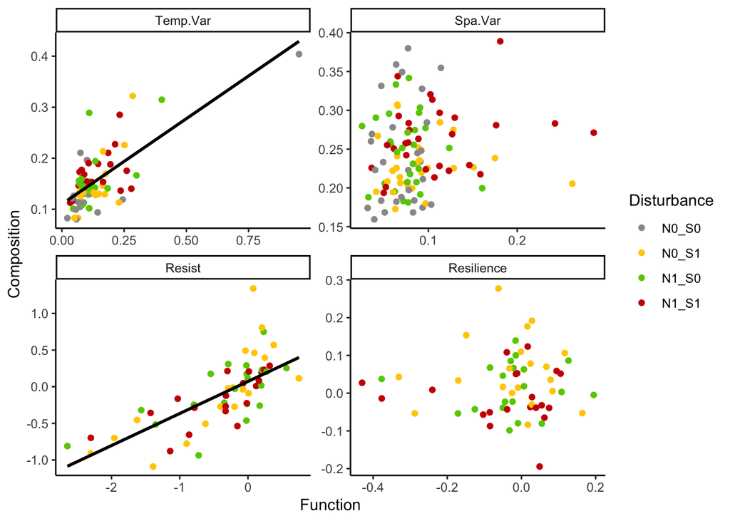

```r
ggplot(combined, aes(x=Function, y=Composition)) +
  geom_point(aes(colour = Disturbance)) +
  theme_classic()+
  scale_colour_manual(values = c("#999999", "#FFCC00","#66CC00", "red3")) +
  facet_wrap(~ metric, scales = "free")+
  geom_smooth(data = subset(combined, metric == "Resist"), aes(x=Function, y=Composition), method = lm, se = FALSE,colour = "black") +
  geom_smooth(data = subset(combined, metric == "Temp.Var"), aes(x=Function, y=Composition), method = lm, se = FALSE, colour = "black")
```

# ANOVA and PEMANOVA results T12

Results for full models with all possible interactions on macroalgae after 12 months of experiment (TAC): Species removed (3 levels: none, whelk, whelk & grazers) Nutrients (2 levels: added, ambient) Enrichment (2 levels: added, ambient)

So unlike the main analysis i have included the mutli-stressor treatment.

## ANOVA

Model on raw data gives slightly non-normally distributed residuals (p =0.03 for shapiro-wilk). Raw model results give sig effect of consumer loss only, TAC in whelk & grazer loss > other treatments

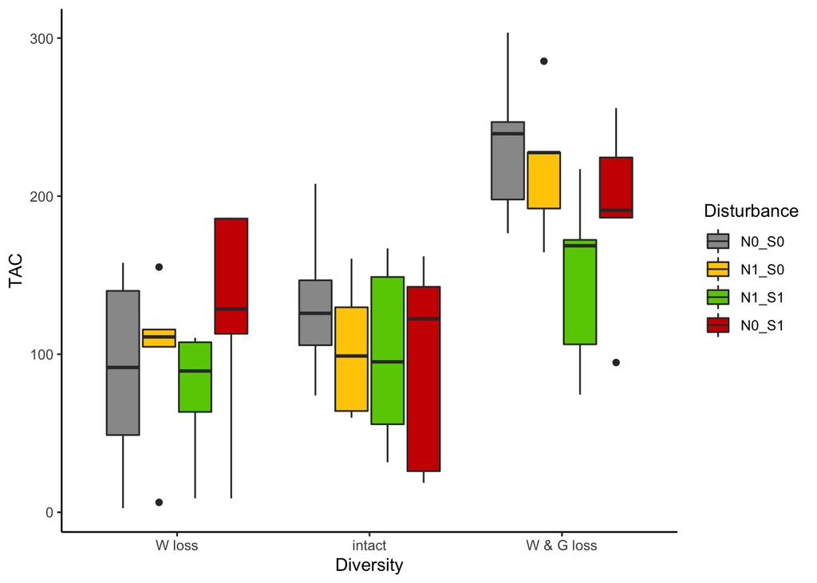

```r
functional_T12<- data%>%
  mutate_if(is.numeric, ~replace(., is.na(.), 0))%>%
   mutate(sum = rowSums(cols)) %>%
   select(Time:Treatment,sum) %>%
    filter(Time == 12 ) %>%
    filter(Diversity != "D" ) %>%
    rename(TAC = `sum`) %>%separate(Treatment, c("Diversity", "Nutrients","Sediment"), remove = F)%>%
  unite(Disturbance,c("Nutrients","Sediment"),sep="_", remove = F)%>%
  mutate(Disturbance = as_factor(Disturbance))%>%
  mutate(Diversity = as_factor(Diversity))

ggplot(functional_T12, aes(x=Diversity, y=TAC))+
  geom_boxplot(aes(fill = Disturbance))+
  scale_fill_manual(values = c("#999999", "#FFCC00","#66CC00","red3"))+
  theme_classic()+
  scale_x_discrete(labels=c("A" = "W & G loss", "B" = "W loss", "C" = "intact"))
```

```r
mod1<-lm(TAC~Diversity*Nutrients*Sediment, data = functional_T12)
leveneTest(TAC~Diversity*Nutrients*Sediment, data = functional_T12)
```

```
## Levene's Test for Homogeneity of Variance (center = median)
##       Df F value Pr(>F)
## group 11  0.2495 0.9918
##       48
```

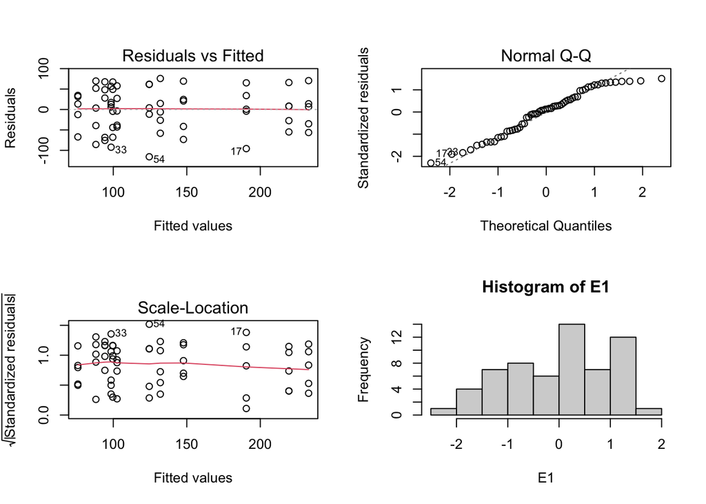

```r
par(mfrow=c(2,2))
plot(mod1,which = c(1,2,3))
E1 <- rstandard(mod1)
F1 <- fitted(mod1)
hist(E1)
```

```r
shapiro.test(E1)
```

```
##
##  Shapiro-Wilk normality test
##
## data:  E1
## W = 0.95527, p-value = 0.02775
```

```r
par(mfrow=c(1,1))
anova(mod1)
```

```
## Analysis of Variance Table
##
## Response: TAC
##                              Df Sum Sq Mean Sq F value    Pr(>F)
## Diversity                     2 123098   61549 19.5356 6.206e-07 ***
## Nutrients                     1   5842    5842  1.8543    0.1796
## Sediment                      1   8282    8282  2.6288    0.1115
## Diversity:Nutrients           2    646     323  0.1025    0.9028
## Diversity:Sediment            2  10281    5141  1.6316    0.2063
## Nutrients:Sediment            1   1188    1188  0.3769    0.5421
## Diversity:Nutrients:Sediment  2   5736    2868  0.9103    0.4092
## Residuals                    48 151229    3151
## ---
## Signif. codes:  0 '***' 0.001 '**' 0.01 '*' 0.05 '.' 0.1 ' ' 1
```

```r
lsmeans(mod1, pairwise~Diversity, adjust="tukey")
```

```
## $lsmeans
##  Diversity lsmean   SE df lower.CL upper.CL
##  B           96.8 12.6 48     71.5      122
##  C          107.1 12.6 48     81.9      132
##  A          197.6 12.6 48    172.4      223
##
## Results are averaged over the levels of: Nutrients, Sediment
## Confidence level used: 0.95
##
## $contrasts
##  contrast estimate   SE df t.ratio p.value
##  B - C       -10.4 17.7 48  -0.583  0.8296
##  B - A      -100.8 17.7 48  -5.681  <.0001
##  C - A       -90.5 17.7 48  -5.098  <.0001
##
## Results are averaged over the levels of: Nutrients, Sediment
## P value adjustment: tukey method for comparing a family of 3 estimates
```

Model on squared data improves normality of residuals but increases heteroscedasticty slightly (but not significantly).

Model on squared data gives sig interaction between sediment and consumer loss: TAC in whelk & grazer loss no sediment > all other treatments

Other trasnfomrations (log and sqrt) made distribution of residuals very non-normal.

```r
mod2<-lm((TAC)^2~Diversity*Nutrients*Sediment, data = functional_T12)
leveneTest(TAC^2~Diversity*Nutrients*Sediment, data = functional_T12)
```

```
## Levene's Test for Homogeneity of Variance (center = median)
##       Df F value Pr(>F)
## group 11  0.7688 0.6685
##       48
```

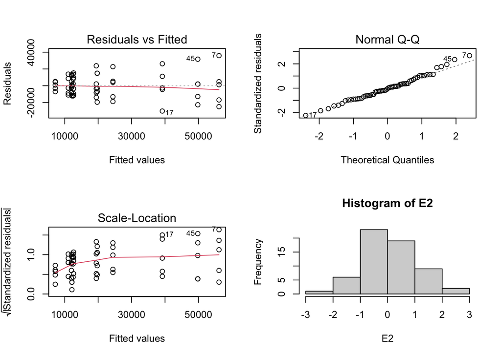

```r
par(mfrow=c(2,2))
plot(mod2,which = c(1,2,3))

E2 <- rstandard(mod2)
F2 <- fitted(mod2)
hist(E2)
```

```r
shapiro.test(E2)
```

```
##
##  Shapiro-Wilk normality test
##
## data:  E2
## W = 0.98608, p-value = 0.7262
```

```r
par(mfrow=c(1,1))
anova(mod2)
```

```
## Analysis of Variance Table
##
## Response: (TAC)^2
##                              Df     Sum Sq    Mean Sq F value    Pr(>F)
## Diversity                     2 1.1280e+10 5640085915 25.0401 3.563e-08 ***
## Nutrients                     1 6.6299e+08  662994628  2.9435   0.09267 .
## Sediment                      1 8.4184e+08  841841305  3.7375   0.05911 .
## Diversity:Nutrients           2 1.2553e+08   62765135  0.2787   0.75802
## Diversity:Sediment            2 1.4648e+09  732413879  3.2517   0.04738 *
## Nutrients:Sediment            1 8.7591e+07   87590809  0.3889   0.53584
## Diversity:Nutrients:Sediment  2 3.0525e+08  152624692  0.6776   0.51262
## Residuals                    48 1.0812e+10  225242014
## ---
## Signif. codes:  0 '***' 0.001 '**' 0.01 '*' 0.05 '.' 0.1 ' ' 1
```

```r
lsmeans(mod2, pairwise~Diversity*Sediment, adjust="tukey")
```

```
## $lsmeans
##  Diversity Sediment lsmean   SE df lower.CL upper.CL
##  B         S0        11605 4746 48     2063    21148
##  C         S0        15719 4746 48     6177    25261
##  A         S0        52972 4746 48    43429    62514
##  B         S1        13443 4746 48     3900    22985
##  C         S1        12575 4746 48     3032    22117
##  A         S1        31804 4746 48    22261    41346
##
## Results are averaged over the levels of: Nutrients
## Results are given on the ( (not the response) scale.
## Confidence level used: 0.95
##
## $contrasts
##  contrast    estimate   SE df t.ratio p.value
##  B S0 - C S0    -4114 6712 48  -0.613  0.9896
##  B S0 - A S0   -41366 6712 48  -6.163  <.0001
##  B S0 - B S1    -1838 6712 48  -0.274  0.9998
##  B S0 - C S1     -970 6712 48  -0.144  1.0000
##  B S0 - A S1   -20199 6712 48  -3.009  0.0451
##  C S0 - A S0   -37252 6712 48  -5.550  <.0001
##  C S0 - B S1     2276 6712 48   0.339  0.9994
##  C S0 - C S1     3144 6712 48   0.468  0.9970
##  C S0 - A S1   -16085 6712 48  -2.396  0.1780
##  A S0 - B S1    39529 6712 48   5.889  <.0001
##  A S0 - C S1    40397 6712 48   6.019  <.0001
##  A S0 - A S1    21168 6712 48   3.154  0.0313
##  B S1 - C S1      868 6712 48   0.129  1.0000
##  B S1 - A S1   -18361 6712 48  -2.736  0.0866
##  C S1 - A S1   -19229 6712 48  -2.865  0.0641
##
## Results are averaged over the levels of: Nutrients
## Note: contrasts are still on the ( scale
## P value adjustment: tukey method for comparing a family of 6 estimates
```

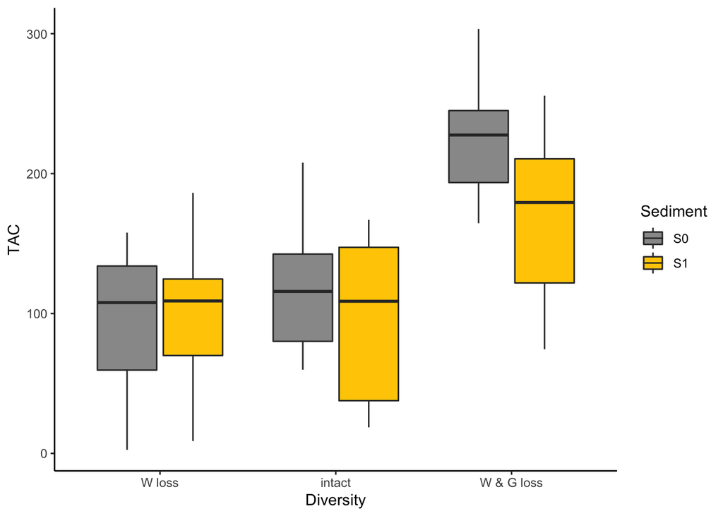

```r
ggplot(functional_T12, aes(x=Diversity, y=TAC))+
  geom_boxplot(aes(fill = Sediment))+
  scale_fill_manual(values = c("#999999", "#FFCC00","#66CC00","red3"))+
  theme_classic()+
  scale_x_discrete(labels=c("A" = "W & G loss", "B" = "W loss", "C" = "intact"))
```

## PERMANOVA

We check for homogeneous dispersion between groups and carry out permanova. Dispersions are homogeneous but used log10 x +1 transformation on data to keep in line with rest of anlalysis. Results are same regardless of transformation, whelk and grazer treatments differ signicantly from other treatments.

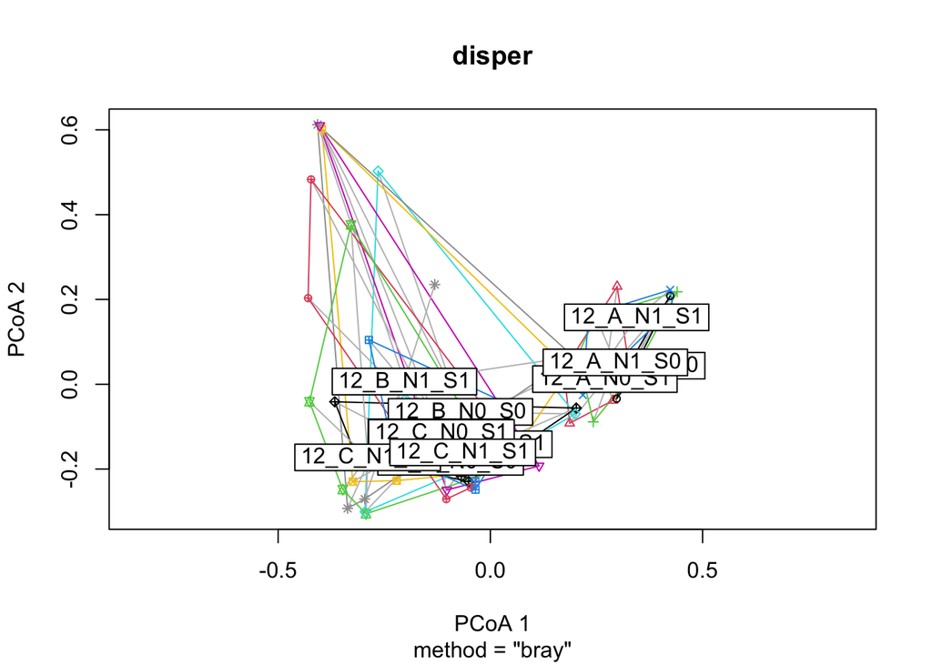

```r
env<- data%>%
  select(Plot, Time:Treatment)%>%
  unite("Treatment_Time", Time,Treatment, remove = FALSE)%>%
  separate(Treatment, c("Diversity", "Nutrients","Sediment"), remove = F)%>%
  unite(Disturbance,c("Nutrients","Sediment"),sep="_", remove = F)%>%
  filter(Time == 12 & Diversity != 'D')

dat<- data%>%
  separate(Treatment, c("Diversity", "Nutrients","Sediment"), remove = F)%>%
  unite(Disturbance,c("Nutrients","Sediment"),sep="_", remove = F)%>%
  unite("Treatment_Time", Time,Treatment, remove = FALSE)%>%
  relocate(Diversity:Disturbance, .after = Treatment)%>%
  filter(Time == 12 & Diversity != 'D')%>%
  mutate(Time = as_factor(Time))%>%
  mutate(Disturbance = as_factor(Disturbance))%>%
  relocate(Nutrients, Sediment,.after = Disturbance)

dist_bc <- vegdist((dat[10:44]), method = 'bray')
disper=betadisper(dist_bc, dat$Treatment_Time)

plot(disper)
```

```r
anova(disper)
```

```
## Analysis of Variance Table
##
## Response: Distances
##           Df  Sum Sq  Mean Sq F value Pr(>F)
## Groups    11 0.46003 0.041821  0.9971 0.4628
## Residuals 48 2.01316 0.041941
```

```r
adonis(log10(1 + dat[10:44]) ~ Diversity*Nutrients*Sediment, data = dat, permutations = 9999)
```

```
##
## Call:
## adonis(formula = log10(1 + dat[10:44]) ~ Diversity * Nutrients *      Sediment, data = dat, permutations = 9999)
##
## Permutation: free
## Number of permutations: 9999
##
## Terms added sequentially (first to last)
##
##                              Df SumsOfSqs MeanSqs F.Model      R2 Pr(>F)
## Diversity                     2    2.9794 1.48969 12.4078 0.31070 0.0001 ***
## Nutrients                     1    0.0980 0.09797  0.8160 0.01022 0.5205
## Sediment                      1    0.0960 0.09595  0.7992 0.01001 0.5408
## Diversity:Nutrients           2    0.1477 0.07386  0.6152 0.01540 0.7950
## Diversity:Sediment            2    0.1940 0.09702  0.8081 0.02024 0.6007
## Nutrients:Sediment            1    0.0728 0.07276  0.6060 0.00759 0.6862
## Diversity:Nutrients:Sediment  2    0.2387 0.11933  0.9939 0.02489 0.4394
## Residuals                    48    5.7629 0.12006         0.60097
## Total                        59    9.5894                 1.00000
## ---
## Signif. codes:  0 '***' 0.001 '**' 0.01 '*' 0.05 '.' 0.1 ' ' 1
```

```r
adonis((dat[10:44]) ~ Diversity*Nutrients*Sediment, data = dat, permutations = 9999)
```

```
##
## Call:
## adonis(formula = (dat[10:44]) ~ Diversity * Nutrients * Sediment,      data = dat, permutations = 9999)
##
## Permutation: free
## Number of permutations: 9999
##
## Terms added sequentially (first to last)
##
##                              Df SumsOfSqs MeanSqs F.Model      R2 Pr(>F)
## Diversity                     2    3.3792 1.68961  9.0600 0.24889 0.0001 ***
## Nutrients                     1    0.0706 0.07055  0.3783 0.00520 0.9021
## Sediment                      1    0.2606 0.26064  1.3976 0.01920 0.2135
## Diversity:Nutrients           2    0.1963 0.09813  0.5262 0.01446 0.8966
## Diversity:Sediment            2    0.2610 0.13051  0.6998 0.01922 0.7338
## Nutrients:Sediment            1    0.1430 0.14300  0.7668 0.01053 0.5799
## Diversity:Nutrients:Sediment  2    0.3150 0.15751  0.8446 0.02320 0.5773
## Residuals                    48    8.9516 0.18649         0.65931
## Total                        59   13.5773                 1.00000
## ---
## Signif. codes:  0 '***' 0.001 '**' 0.01 '*' 0.05 '.' 0.1 ' ' 1
```

```r
pairwise.adonis(log10(1 + dat[10:44]), dat$Diversity)
```

```
## [1] "Signif. codes:  0 ‘***’ 0.001 ‘**’ 0.01 ‘*’ 0.05 ‘.’ 0.1 ‘ ’ 1"
```

```
##    pairs   F.Model         R2 p.value p.adjusted sig
## 1 B vs C  0.810475 0.02088289   0.480      1.000
## 2 B vs A 16.622660 0.30431802   0.001      0.003   *
## 3 C vs A 28.617069 0.42957562   0.001      0.003   *
```